## Homework Assignment 4

#### Due Friday, February 24 at 11:59 PM CT

### Preliminaries

- Directories
  - COURSE/homework/
  - COURSE/homework/hw04/
  - COURSE/data/
  - COURSE/scripts/
- Files
  - COURSE/homework/hw04/hw04.Rmd
  - COURSE/data/ORD-2017.csv
  - COURSE/data/ORD-2018.csv
  - COURSE/data/ORD-2019.csv
  - COURSE/data/ORD-2020.csv
  - COURSE/data/ORD-2021.csv
  - COURSE/scripts/viridis.R

### Aims

- Practice data visualization using ggplot2
- Practice data wrangling with dplyr
- Practice reading in data and working with dates
- Explore additional airport waiting time data

### Problems

This assignment involves five data sets involving international flights arriving to Chicago’s O’Hare airport from January 1, 2017 through December 31, 2021 with one separate file for each year. Each file has been cleaned from the original HTML.

Each data set is in a separate CSV file: `ORD-2017.csv`, `ORD-2018.csv`, `ORD-2019.csv`, `ORD-2020.csv`, `ORD-2021.csv`.

This code chunk reads in these five data sets and combines them into a single data set.

```r
ord = map_dfr(2017:2021, ~{
  return ( read_csv(str_c("../../data/ORD-", .x, ".csv")) )
})
```

1. Make the following changes to the data set `ord`.
- Add columns for:
  - *year*;
  - *month* (character valued, use month abbreviations, Jan - Dec);
  - *day* (day of the month); and
  - *wday* (day of the week, character valued, use day abbreviations, Sun - Sat).
- Reorder the variables so that these new variables all appear directly after the date column.
- Remove the `terminal` variable.
- Rename:
  - *all_total* to *passengers*;
  - *all_flights* to *flights*; and
  - *all_booths* to *booths*.
- Arrange the rows by date and hour.
- Print all columns of the first 5 rows of this modified data frame
- Print the dimensions of this modified data frame

```r
ord = ord %>%
  subset(select = -c(terminal)) %>%
  mutate(year = year(date),
         month = month(date),
         day = day(date),
         wday = wday(date)) %>%
  rename("passengers" = "all_total",
         "flights"="all_flights",
         "booths"="all_booths") %>%
  select(airport, date, year, month, wday, hour, us_avg_wait, us_max_wait, non_us_avg_wait, non_us_max_wait, all_avg_wait,
         all_max_wait, all_n_0_15, all_n_16_30, all_n_31_45, all_n_46_60, all_n_61_90, all_n_91_120, all_n_120_plus,
         all_excluded, passengers, flights, booths) %>%
  arrange(date, hour)
```

```r
ord %>%
  select(airport, date, year, month, wday, hour, us_avg_wait, us_max_wait, non_us_avg_wait, non_us_max_wait, all_avg_wait,
         all_max_wait, all_n_0_15, all_n_16_30, all_n_31_45, all_n_46_60, all_n_61_90, all_n_91_120, all_n_120_plus,
         all_excluded, passengers, flights, booths) %>%
  arrange(date, hour) %>%
  slice_max(all_n_16_30, n=5)
```

```
## # A tibble: 5 × 23
##   airport date        year month  wday hour      us_av…¹ us_ma…² non_u…³ non_u…⁴
##   <chr>   <date>     <dbl> <dbl> <dbl> <chr>       <dbl>   <dbl>   <dbl>   <dbl>
## 1 ORD     2019-06-22  2019     6     7 1300 - 1…      20      98      33     100
## 2 ORD     2019-06-09  2019     6     1 1300 - 1…      16      70      25      95
## 3 ORD     2018-07-28  2018     7     7 1500 - 1…      20      47      26      55
## 4 ORD     2018-07-09  2018     7     2 1300 - 1…      17      67      24      68
## 5 ORD     2019-06-16  2019     6     1 1300 - 1…      17      75      29      83
## # … with 13 more variables: all_avg_wait <dbl>, all_max_wait <dbl>,
## #   all_n_0_15 <dbl>, all_n_16_30 <dbl>, all_n_31_45 <dbl>, all_n_46_60 <dbl>,
## #   all_n_61_90 <dbl>, all_n_91_120 <dbl>, all_n_120_plus <dbl>,
## #   all_excluded <dbl>, passengers <dbl>, flights <dbl>, booths <dbl>, and
## #   abbreviated variable names ¹us_avg_wait, ²us_max_wait, ³non_us_avg_wait,
## #   ⁴non_us_max_wait
```

```r
x=23 * 5
x
```

```
## [1] 115
```

2. Are there any dates in the range from January 1, 2017 through December 31, 2021 that are missing? If so, which ones?

```r
ord %>%
  drop_na()
```

```
## # A tibble: 31,344 × 23
##    airport date        year month  wday hour     us_av…¹ us_ma…² non_u…³ non_u…⁴
##    <chr>   <date>     <dbl> <dbl> <dbl> <chr>      <dbl>   <dbl>   <dbl>   <dbl>
##  1 ORD     2017-01-01  2017     1     1 0700 - …       7      24      12      26
##  2 ORD     2017-01-01  2017     1     1 0800 - …       5      25      13      37
##  3 ORD     2017-01-01  2017     1     1 0900 - …       5      37      32      53
##  4 ORD     2017-01-01  2017     1     1 1000 - …       8      20       8      19
##  5 ORD     2017-01-01  2017     1     1 1100 - …      30      89      40      89
##  6 ORD     2017-01-01  2017     1     1 1200 - …      19      83      39      92
##  7 ORD     2017-01-01  2017     1     1 1300 - …      10      51      17      55
##  8 ORD     2017-01-01  2017     1     1 1400 - …      10      63      23      70
##  9 ORD     2017-01-01  2017     1     1 1500 - …      14      66      31      69
## 10 ORD     2017-01-01  2017     1     1 1600 - …      13      44      24      47
## # … with 31,334 more rows, 13 more variables: all_avg_wait <dbl>,
## #   all_max_wait <dbl>, all_n_0_15 <dbl>, all_n_16_30 <dbl>, all_n_31_45 <dbl>,
## #   all_n_46_60 <dbl>, all_n_61_90 <dbl>, all_n_91_120 <dbl>,
## #   all_n_120_plus <dbl>, all_excluded <dbl>, passengers <dbl>, flights <dbl>,
## #   booths <dbl>, and abbreviated variable names ¹us_avg_wait, ²us_max_wait,
## #   ³non_us_avg_wait, ⁴non_us_max_wait
```

```r
ord = ord %>%
  mutate(time_of_day = case_when(hour < "0400" ~ "overnight",
                                 hour < "0800" ~ "early morning",
                                 hour < "1200" ~ "morning",
                                 hour < "1600" ~ "afternoon",
                                 hour < "2000" ~ "early evening",
                                 hour < "2400" ~ "late evening"),
           fct_relevel(time_of_day,
                       c("overnight", "early morning", "morning", "afternoon", "early evening", "late evening")))
```

- Create a summary table which counts the number of rows for each `time_of_day` and `hour` combination. Verify that the top ten rows of your data set match these values.

```
   time_of_day   hour            n
   <fct>         <chr>       <int>
 1 overnight     0000 - 0100  1345
 2 overnight     0100 - 0200   538
 3 overnight     0200 - 0300   167
 4 overnight     0300 - 0400   125
 5 early morning 0400 - 0500   520
 6 early morning 0500 - 0600  1024
 7 early morning 0600 - 0700  1355
 8 early morning 0700 - 0800  1286
 9 morning       0800 - 0900  1434
10 morning       0900 - 1000  1447
```

```r
ord %>%
  select(time_of_day, hour) %>%
  group_by(time_of_day, hour) %>%
  summarize(n=n()) %>%
  arrange(hour)
```

[output not shown]

```
## Error in `select()`:
## ! Can't subset columns that don't exist.
## ✖ Column `time_of_day` doesn't exist.
```

- Create an additional summary table which calculates the total number of flights which arrive during each of these time periods. This table will have six rows.
- Print the table.

```r
ord %>%
  select(airport, hour, time_of_day, flights) %>%
  group_by(airport, hour, time_of_day) %>%
  summarize(sum_flights = sum(flights)) %>%
  ungroup() %>%
  slice_max(hour, n=6)
```

[output not shown]

```
## Error in `select()`:
## ! Can't subset columns that don't exist.
## ✖ Column `time_of_day` doesn't exist.
```

4. Use a bar graph to display the total number of flights in each time period as calculated in the previous problem. There should be six categories of time period from “overnight” to “late evening”. Add a title and meaningful axis labels.

```r
ggplot(ord, aes(x = time_of_day, y = flights)) +
  geom_histogram(stat = "identity", binwidth = 1, fill = "Green", color = "Green")+  xlab("Times of Day")+
  ylab("Number of Flights")+
  ggtitle("Number of flights during the Days/Nights")
```

[output not shown]

```
## Error in `geom_histogram()`:
## ! Problem while computing aesthetics.
## ℹ Error occurred in the 1st layer.
## Caused by error in `FUN()`:
## ! object 'time_of_day' not found
```

5. Create a data summary table with the average daily number of passengers by month and year.
- Display this data summary with a bar chart where month is on the x-axis and average daily passenger counts are on the y axis
- Add meaningful axis labels and a title to this graph.
- Change the y axis scale labels so values are regular numbers with commas. *(Use `scale_y_continuous()` as below)*
- Display the graph with a different facet for each year

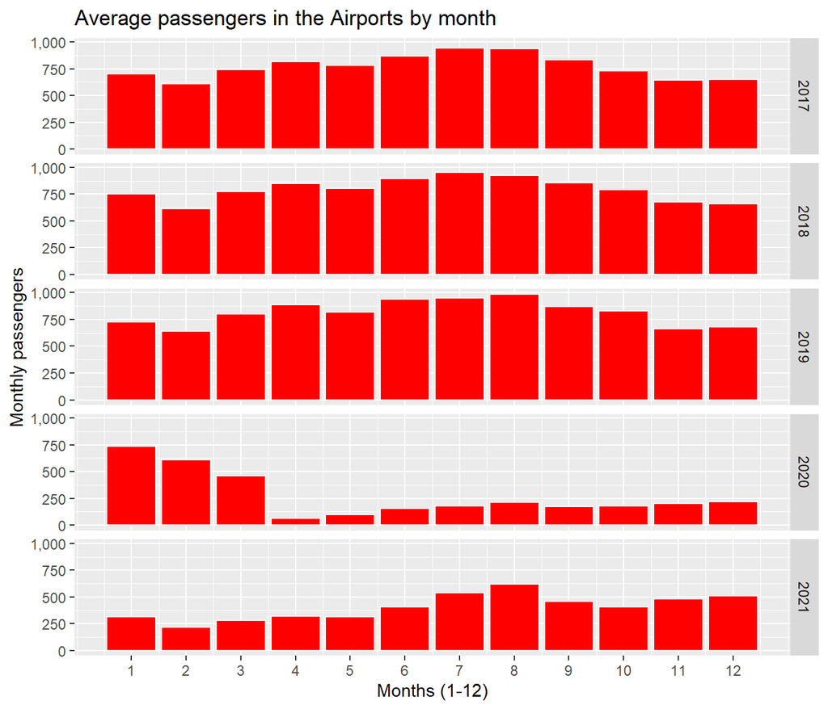

```r
## modify this code block

## data summary
prob5 = ord %>%
  mutate(year = year(date),
         month = month(date)) %>%
  select(airport, year, month, passengers, flights) %>%
  group_by(airport, year, month) %>%
  summarize(avg_daily_passengers = mean(passengers),
            avg_daily_flights = mean(flights))
  ## add code

## plot the table
ggplot(prob5, aes(x = month, y = avg_daily_passengers)) +
  geom_histogram(stat = "identity",binwidth = 1, fill = "red", color = "white")+
  scale_y_continuous(label = scales::comma)+
  scale_x_continuous(breaks = seq(from =1, to = 12, by=1)) +
  xlab("Months (1-12)")+
  ylab("Monthly passengers")+
  ggtitle("Average passengers in the Airports by month")+
  facet_grid(rows = vars(year))
```

```r
  ### ADD MORE OF YOUR CODE HERE
```

6. What striking feature is apparent in this graph? What explains this feature of the data?

> in 2020, the boxes are much smaller due to COVID, so the feature of this data is to see when the airports were the most popular
7. Investigate the average number of passengers per day of the week for the years 2017–2019.
- For each day of the week (Sunday – Saturday), calculate the average number of arriving daily passengers to ORD on international flights. Display this table sorted from highest to lowest average. *(Hint: you need to total passengers by date and day of week before taking averages.)*
- Print the entire table

```r
ordavg = ord %>%
  mutate(Day_of_the_week = wday(date),
         year = year(date)) %>%
  select(airport, Day_of_the_week, date,year, passengers, flights) %>%
  filter(year(date) != 2020) %>%
  filter(year(date) != 2021) %>%
  group_by(airport, Day_of_the_week,year, date) %>%
  summarize(avg_passengers = mean(passengers)) %>%
  arrange(desc(avg_passengers))
ordavg
```

```
## # A tibble: 1,091 × 5
## # Groups:   airport, Day_of_the_week, year [21]
##    airport Day_of_the_week  year date       avg_passengers
##    <chr>             <dbl> <dbl> <date>              <dbl>
##  1 ORD                   1  2018 2018-04-08          1187.
##  2 ORD                   7  2018 2018-01-06          1137.
##  3 ORD                   6  2018 2018-06-29          1125.
##  4 ORD                   7  2019 2019-08-03          1117.
##  5 ORD                   1  2018 2018-07-29          1107.
##  6 ORD                   1  2019 2019-07-21          1101.
##  7 ORD                   1  2019 2019-07-28          1097.
##  8 ORD                   5  2018 2018-01-04          1096.
##  9 ORD                   4  2019 2019-08-07          1093.
## 10 ORD                   7  2019 2019-08-17          1092.
## # … with 1,081 more rows
```

8. Identify the 20 dates with the highest total number of arriving passengers. How many of these dates are the day of the week identified in the previous problem with the highest average?

```r
ordmax = ord %>%
  select(airport, date, passengers) %>%
  arrange(desc(passengers)) %>%
  slice_max(passengers, n=20)
ordmax
```

```
## # A tibble: 20 × 3
##    airport date       passengers
##    <chr>   <date>          <dbl>
##  1 ORD     2017-10-21       3779
##  2 ORD     2019-06-22       3710
##  3 ORD     2019-09-02       3682
##  4 ORD     2019-07-22       3623
##  5 ORD     2019-06-25       3535
##  6 ORD     2019-07-21       3529
##  7 ORD     2019-05-27       3432
##  8 ORD     2018-07-22       3401
##  9 ORD     2018-07-23       3391
## 10 ORD     2018-08-25       3381
## 11 ORD     2017-07-18       3377
## 12 ORD     2017-07-08       3376
## 13 ORD     2019-04-19       3374
## 14 ORD     2017-07-08       3372
## 15 ORD     2018-08-11       3372
## 16 ORD     2018-07-31       3364
## 17 ORD     2018-09-08       3356
## 18 ORD     2019-03-23       3352
## 19 ORD     2017-07-05       3347
## 20 ORD     2019-08-23       3343
```